# DEAP_n_queens_on_canvas

## Project 4: Solving N-Queens Problem using Genetic Algorithms

#### CSC 180 Intelligent Systems

#### Dr. Haiquan Chen, California State University, Sacramento

```python
#Ezekiel Sung ID:219507107
#Hung Truong ID:301035748
#CSC180
#Project 4
#Due:4/23/21
```

## Part I: Position-index-based board representation

```python
import random
import numpy as np
from deap import algorithms, base, creator, tools
import matplotlib.pyplot as plt
%matplotlib inline


creator.create("FitnessMin", base.Fitness, weights=(-1.0,))
creator.create("Individual", list, fitness=creator.FitnessMin)
```

```python
def create_individual():
    return random.sample(range(64), 8)
```

```python
print(create_individual())
```

```
[39, 26, 52, 38, 4, 55, 50, 44]
```

```python
def show_grid(board):

    n = [0]*64
    for i in board:
        n[i] = 1


    for i in range(8):
        for j in range(64):
            if j // 8 == i:
                if n[j] == 1:
                    print('X',end="|")
                else:
                    print('-',end="|")
        print()
        print("----------------")
```

```python
toolbox = base.Toolbox()

toolbox.register("individual", tools.initIterate, creator.Individual, create_individual)

toolbox.register("population", tools.initRepeat, list, toolbox.individual)
```

```python
pop = toolbox.population(n=5)

print(pop[1])
```

```
[12, 61, 36, 15, 23, 26, 45, 17]
```

```python
show_grid(pop[1])
```

```
-|-|-|-|-|-|-|-|
----------------
-|-|-|-|X|-|-|X|
----------------
-|X|-|-|-|-|-|X|
----------------
-|-|X|-|-|-|-|-|
----------------
-|-|-|-|X|-|-|-|
----------------
-|-|-|-|-|X|-|-|
----------------
-|-|-|-|-|-|-|-|
----------------
-|-|-|-|-|X|-|-|
----------------
```

### 10 pts: Write your code in the cell below to define the "evaFitness" function, which returns the fitness of any given board.

- Noticed that in this case, mutation may generate invalid board, e.g., the board with dupliciate positions. Think about [5, 32, 8, 8, 41, 3, 55, 49]
- How to exclude those invalid boards from each generation? One way is to add some penalty to the fitness value of invalid boards. In that case, any invalid board will have a very high fitness value (remember that our goal is to find the board with least fitness value). To do that, let's write a function *checkDuplicate()* to calculate the number of queen pairs in the same position for any given board. *Give each duplicate a high penalty (i.e., multiply by 20, 50) and add the penalty to the fitness value.*
- evaFitness() returns the total number of duplicate position pair (with penalty) plus the total number of distinct pairs of queens that attack each other.

```python
#fitness function
def evaFitness(individual):

    conflict = 0
    for x in range(8):

        #check diagonals
        left = individual[x] % 8
        right = 7-left

        #check left
        for i in range(1,left+1):
            if individual[x]+(7*i) in individual:
                conflict+=1

        #check right
        for i in range(1,right+1):
            #check horizontal
            if individual[x]+i in individual:
                conflict+=1
            if individual[x]+(9*i) in individual:
                conflict+=1

    #check vertical conflicts

        check=individual[x]+8
        while check<64:
            if check in individual:
                conflict+=1
            check+=8
    return (checkDuplicate(individual) + conflict,)

# Calculate the number of queen pairs in the same position for any given board
def checkDuplicate(individual):
    dup = 0

    (unique, counts) = np.unique(individual, return_counts=True)
    freq = np.asarray((unique,counts)).T

    for x in range(len(freq)):
        if freq[x][1]!=1:
            dup=dup+freq[x][1]-1

    dup=dup*50

    return dup
```

### 5 pts: Writer your code in the cell below to register "evaluate" function to toolbox

```python
toolbox.register("evaluate", evaFitness)
```

```python
toolbox.register("mate", tools.cxTwoPoint)

toolbox.register("mutate", tools.mutUniformInt, low = 0, up = 63, indpb=0.1)

toolbox.register("select", tools.selTournament, tournsize=3)
```

```python
stats = tools.Statistics(key=lambda ind: ind.fitness.values)
```

```python
stats.register("avg", np.mean)
stats.register("min", np.min)
```

### 10 pts: Writer your code in the cell below to create the first generation, the hall of fame, and launch the genetic algorithm: eaSimple(). How many individuals you want to have for each generation and how many generations you want GA to go thourgh for each run? Vary those two parameters to see the change.

Trial 1

```python
stats = tools.Statistics(key=lambda ind: ind.fitness.values)
stats.register("avg", np.mean)
stats.register("min", np.min)
pop = toolbox.population(n=100)
hof = tools.HallOfFame(maxsize=1)
pop, log = algorithms.eaSimple(pop, toolbox, cxpb=0.5, mutpb=0.2, ngen=100,
                                   stats=stats, halloffame=hof, verbose=True)
```

```
gen	nevals	avg  	min
0  	100   	10.29	5
1  	67    	18.79	5
2  	52    	12.11	4
3  	58    	13.41	4
4  	67    	11.1 	4
5  	62    	12.12	3
6  	58    	7.18 	3
7  	53    	7.75 	3
8  	57    	8.78 	3
9  	46    	7.65 	3
10 	61    	7.15 	3
11 	62    	6.85 	3
12 	52    	4.81 	3
13 	62    	4.84 	2
```

[output cut: 87 more lines]

Trial 2 (Increase Population)

```python
stats = tools.Statistics(key=lambda ind: ind.fitness.values)
stats.register("avg", np.mean)
stats.register("min", np.min)
pop = toolbox.population(n=500)
hof = tools.HallOfFame(maxsize=1)
pop, log = algorithms.eaSimple(pop, toolbox, cxpb=0.5, mutpb=0.2, ngen=100,
                                   stats=stats, halloffame=hof, verbose=True)
```

```
gen	nevals	avg  	min
0  	500   	9.918	3
1  	284   	13.17	3
2  	329   	12.1 	3
3  	303   	11.36	3
4  	291   	11.5 	3
5  	294   	10.124	3
6  	333   	9.626 	3
7  	294   	9.216 	3
8  	303   	9.024 	3
9  	290   	8.794 	2
10 	307   	7.768 	2
11 	306   	6.336 	2
12 	299   	4.98  	2
13 	290   	4.912 	2
```

[output cut: 87 more lines]

Trial 3 (Increase Crossover)

```python
stats = tools.Statistics(key=lambda ind: ind.fitness.values)
stats.register("avg", np.mean)
stats.register("min", np.min)
pop = toolbox.population(n=100)
hof = tools.HallOfFame(maxsize=1)
pop, log = algorithms.eaSimple(pop, toolbox, cxpb=0.9, mutpb=0.2, ngen=100,
                                   stats=stats, halloffame=hof, verbose=True)
```

```
gen	nevals	avg  	min
0  	100   	10.13	5
1  	94    	19.88	4
2  	96    	15.62	6
3  	86    	14.9 	4
4  	96    	16.83	4
5  	84    	17.08	4
6  	93    	13.02	4
7  	96    	15.86	2
8  	95    	12   	4
9  	83    	11.73	3
10 	89    	8.57 	3
11 	94    	8.19 	3
12 	91    	5.12 	3
13 	95    	5.28 	3
```

[output cut: 87 more lines]

Trial 4 (Increase Mutation Probability)

```python
stats = tools.Statistics(key=lambda ind: ind.fitness.values)
stats.register("avg", np.mean)
stats.register("min", np.min)
pop = toolbox.population(n=100)
hof = tools.HallOfFame(maxsize=1)
pop, log = algorithms.eaSimple(pop, toolbox, cxpb=0.5, mutpb=0.7, ngen=100,
                                   stats=stats, halloffame=hof, verbose=True)
```

```
gen	nevals	avg  	min
0  	100   	10.03	4
1  	90    	15.4 	5
2  	87    	16.94	4
3  	87    	14.94	4
4  	87    	15.18	4
5  	89    	12.95	4
6  	84    	12.38	3
7  	83    	9.74 	3
8  	81    	9.85 	3
9  	86    	11.59	3
10 	81    	9.56 	3
11 	88    	8.2  	3
12 	88    	7.97 	2
13 	78    	6.35 	2
```

[output cut: 87 more lines]

Trial 5 (Increase Generations)

```python
stats = tools.Statistics(key=lambda ind: ind.fitness.values)
stats.register("avg", np.mean)
stats.register("min", np.min)
pop = toolbox.population(n=100)
hof = tools.HallOfFame(maxsize=1)
pop, log = algorithms.eaSimple(pop, toolbox, cxpb=0.5, mutpb=0.2, ngen=200,
                                   stats=stats, halloffame=hof, verbose=True)
```

```
gen	nevals	avg  	min
0  	100   	10.16	6
1  	55    	16.99	6
2  	57    	14.63	4
3  	65    	16.79	4
4  	53    	13.67	4
5  	62    	13.31	4
6  	69    	12.58	4
7  	64    	12.92	4
8  	53    	10.59	4
9  	56    	9.34 	3
10 	65    	8.27 	3
11 	55    	7.8  	3
12 	66    	5.65 	3
13 	67    	4.91 	2
14 	64    	4.71 	2
15 	54    	3.67 	2
16 	57    	3.02 	2
17 	59    	3.17 	2
18 	60    	4.94 	2
19 	70    	2.71 	2
20 	58    	3.19 	2
21 	66    	3.91 	2
22 	47    	3.32 	2
23 	58    	4    	2
24 	55    	2.73 	2
25 	70    	4.17 	2
26 	49    	3.32 	2
27 	50    	2.84 	2
28 	47    	3.63 	2
29 	55    	2.83 	2
30 	65    	2.38 	2
31 	61    	2.78 	2
32 	61    	2.3  	2
33 	52    	2.48 	2
34 	54    	2.93 	2
35 	63    	2.31 	2
36 	63    	2.73 	1
37 	63    	4.74 	1
38 	63    	2.84 	1
```

[output cut: 147 more lines]

```
186	68    	1.75 	0
187	54    	1.38 	0
188	55    	1.3  	0
189	49    	1.46 	0
190	64    	1.63 	0
191	68    	2.43 	0
192	62    	1.36 	0
193	61    	0.86 	0
194	56    	0.75 	0
195	56    	1.73 	0
196	67    	1.89 	0
197	68    	0.13 	0
198	63    	0.92 	0
199	65    	0.39 	0
200	64    	1.73 	0
```

Trial 6 (Best Combination of Parameters)

```python
stats = tools.Statistics(key=lambda ind: ind.fitness.values)
stats.register("avg", np.mean)
stats.register("min", np.min)
pop = toolbox.population(n=500)
hof = tools.HallOfFame(maxsize=1)
pop, log = algorithms.eaSimple(pop, toolbox, cxpb=0.5, mutpb=0.2, ngen=15,
                                   stats=stats, halloffame=hof, verbose=True)
```

```
gen	nevals	avg   	min
0  	500   	10.172	3
1  	304   	14.462	3
2  	305   	12.86 	3
3  	289   	12.464	3
4  	294   	11.532	2
5  	299   	11.226	2
6  	287   	13.776	2
7  	302   	12.03 	1
8  	292   	9.136 	1
9  	301   	5.176 	1
10 	296   	4.072 	1
11 	295   	3.81  	1
12 	278   	3.378 	1
13 	303   	2.736 	1
14 	304   	2.518 	0
15 	307   	2.046 	0
```

### 5 pts: Plot the "avg" and "min" for each generation

Trial 1

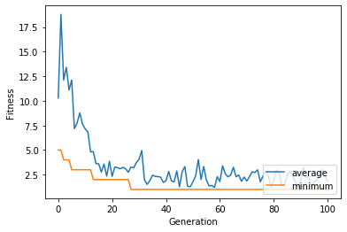

```python
gen, avg, min_,= log.select("gen", "avg", "min")

plt.plot(gen, avg, label="average")
plt.plot(gen, min_, label="minimum")
plt.xlabel("Generation")
plt.ylabel("Fitness")
plt.legend(loc="lower right")
plt.show()
```

Trial 2 (Increase Population)

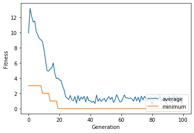

```python
gen, avg, min_,= log.select("gen", "avg", "min")

plt.plot(gen, avg, label="average")
plt.plot(gen, min_, label="minimum")
plt.xlabel("Generation")
plt.ylabel("Fitness")
plt.legend(loc="lower right")
plt.show()
```

Trial 3 (Increase Crossover)

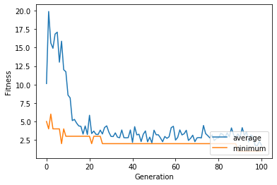

```python
gen, avg, min_,= log.select("gen", "avg", "min")

plt.plot(gen, avg, label="average")
plt.plot(gen, min_, label="minimum")
plt.xlabel("Generation")
plt.ylabel("Fitness")
plt.legend(loc="lower right")
plt.show()
```

Trial 4 (Increase Mutation)

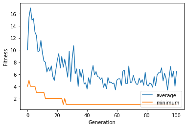

```python
gen, avg, min_,= log.select("gen", "avg", "min")

plt.plot(gen, avg, label="average")
plt.plot(gen, min_, label="minimum")
plt.xlabel("Generation")
plt.ylabel("Fitness")
plt.legend(loc="lower right")
plt.show()
```

Trial 5 (Increase Generation)

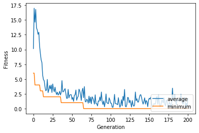

```python
gen, avg, min_,= log.select("gen", "avg", "min")

plt.plot(gen, avg, label="average")
plt.plot(gen, min_, label="minimum")
plt.xlabel("Generation")
plt.ylabel("Fitness")
plt.legend(loc="lower right")
plt.show()
```

Trial 6 (Best Combination of Parameters)

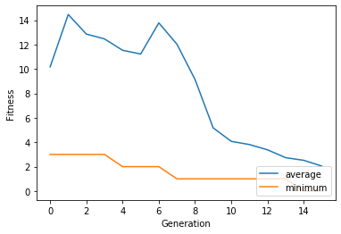

```python
gen, avg, min_,= log.select("gen", "avg", "min")

plt.plot(gen, avg, label="average")
plt.plot(gen, min_, label="minimum")
plt.xlabel("Generation")
plt.ylabel("Fitness")
plt.legend(loc="lower right")
plt.show()
```

### 5 pts: Print out the best individual found and its fitness value. Show the best individual as chessboard

HOF of Trial 6

```python
hof[0]
```

```
[4, 24, 58, 41, 19, 15, 38, 53]
```

```python
show_grid(hof[0])
print("\nwith fitness: ", hof[0].fitness)
```

```
-|-|-|-|X|-|-|-|
----------------
-|-|-|-|-|-|-|X|
----------------
-|-|-|X|-|-|-|-|
----------------
X|-|-|-|-|-|-|-|
----------------
-|-|-|-|-|-|X|-|
----------------
-|X|-|-|-|-|-|-|
----------------
-|-|-|-|-|X|-|-|
----------------
-|-|X|-|-|-|-|-|
----------------

with fitness:  (0.0,)
```

## Part II: Row-index-based board representation

```python
import random
import numpy as np
from deap import algorithms, base, creator, tools

creator.create("FitnessMin", base.Fitness, weights=(-1.0,))
creator.create("Individual", list, fitness=creator.FitnessMin)
```

Each row of the chess row is indexed from 0->7 . we place different queens on different rows initially. The sequence [ a b c d .... ] means that in $0^{th}$ row, $a^{th}$ column, the queen is present and so on

```python
toolbox = base.Toolbox()

toolbox.register("attr_int", random.randint, 0, 7)
toolbox.register("individual", tools.initRepeat, creator.Individual,
                 toolbox.attr_int, n=8)
```

```python
toolbox.individual()
```

```
[1, 4, 4, 7, 3, 1, 0, 7]
```

```python
def show_grid(board):

    n = [0]*64

    for i in range(len(board)):
        n[board[i] + i*8] = 1


    for i in range(8):
        for j in range(64):
            if j // 8 == i:
                if n[j] == 1:
                    print('X',end="|")
                else:
                    print('-',end="|")
        print()
        print("----------------")
```

```python
toolbox.register("population", tools.initRepeat, list, toolbox.individual)
```

```python
pop = toolbox.population(n=5)

print(pop[0])
```

```
[2, 5, 6, 1, 7, 5, 0, 3]
```

```python
show_grid(pop[0])
```

```
-|-|X|-|-|-|-|-|
----------------
-|-|-|-|-|X|-|-|
----------------
-|-|-|-|-|-|X|-|
----------------
-|X|-|-|-|-|-|-|
----------------
-|-|-|-|-|-|-|X|
----------------
-|-|-|-|-|X|-|-|
----------------
X|-|-|-|-|-|-|-|
----------------
-|-|-|X|-|-|-|-|
----------------
```

### 10 pts: Write your code in the cell below to define the "evaFitness" function, which return the fitness of any given board

- evaFitness() returns the total number of distinct pairs of queens that attack each other.
- The following are some test cases you may use to verify the correctness of the evaFitness() function:
  - evaFitness([0, 2, 6, 7, 7, 4, 1, 6]) should return (4,)
  - evaFitness([7, 5, 2, 4, 3, 1, 3, 5]) should return (6,)
  - evaFitness([3, 1, 6, 0, 5, 7, 2, 1]) should return (5,)
  - evaFitness([7, 3, 1, 4, 5, 1, 3, 5]) should return (6,)

```python
#fitness function
def evaFitness(individual):

    conflict = 0

    #vertical
    for x in range(8):
        for i in range(x+1,8):
            if individual[x]==individual[i]:
                conflict+=1

    #diagonally

    for current in range(8):
        for check in range(current+1,8):
            temp = check-current
            if individual[current] + temp == individual[check]:
                conflict+=1
            if individual[current] - temp==individual[check]:
                conflict+=1

    return (conflict,)
```

### 5 pts: Writer your code in the cell below to register "evaluate" function to toolbox

```python
toolbox.register("evaluate", evaFitness)
```

```python
toolbox.register("mate", tools.cxTwoPoint)

toolbox.register("mutate", tools.mutUniformInt, low = 0, up = 7, indpb=0.1)

toolbox.register("select", tools.selTournament, tournsize=3)
```

```python
stats = tools.Statistics(key=lambda ind: ind.fitness.values)

stats.register("avg", np.mean)
stats.register("min", np.min)
```

### 10 pts: Writer your code in the cell below to create the first generation, the hall of fame, and launch the genetic algorithm: eaSimple(). How many individuals you want to have for each generation and how many generations you want GA to go thourgh for each run? Vary those two parameters to see the change.

Trial 1

```python
stats = tools.Statistics(key=lambda ind: ind.fitness.values)
stats.register("avg", np.mean)
stats.register("min", np.min)
pop = toolbox.population(n=100)
hof = tools.HallOfFame(maxsize=1)
pop, log = algorithms.eaSimple(pop, toolbox, cxpb=0.5, mutpb=0.2, ngen=100,
                                   stats=stats, halloffame=hof, verbose=True)
```

```
gen	nevals	avg 	min
0  	100   	7.66	3
1  	60    	6.43	2
2  	57    	5.24	2
3  	68    	4.61	2
4  	55    	4.45	2
5  	56    	3.81	2
6  	61    	3.49	2
7  	62    	3.31	2
8  	61    	2.65	2
9  	59    	2.57	2
10 	63    	2.43	1
11 	60    	2.32	1
12 	66    	1.88	1
13 	75    	1.75	1
```

[output cut: 87 more lines]

Trial 2 (Increase population)

```python
stats = tools.Statistics(key=lambda ind: ind.fitness.values)
stats.register("avg", np.mean)
stats.register("min", np.min)
pop = toolbox.population(n=500)
hof = tools.HallOfFame(maxsize=1)
pop, log = algorithms.eaSimple(pop, toolbox, cxpb=0.5, mutpb=0.2, ngen=100,
                                   stats=stats, halloffame=hof, verbose=True)
```

```
gen	nevals	avg  	min
0  	500   	7.964	2
1  	295   	6.412	1
2  	327   	5.604	1
3  	292   	5.034	1
4  	288   	4.602	1
5  	305   	4.402	1
6  	294   	4.018	1
7  	308   	3.802	1
8  	293   	3.558	1
9  	296   	3.384	1
10 	322   	3.334	1
11 	288   	2.924	1
12 	310   	2.462	1
13 	298   	2.158	1
```

[output cut: 87 more lines]

Trial 3 (Increase cross mutation)

```python
stats = tools.Statistics(key=lambda ind: ind.fitness.values)
stats.register("avg", np.mean)
stats.register("min", np.min)
pop = toolbox.population(n=100)
hof = tools.HallOfFame(maxsize=1)
pop, log = algorithms.eaSimple(pop, toolbox, cxpb=0.9, mutpb=0.2, ngen=100,
                                   stats=stats, halloffame=hof, verbose=True)
```

```
gen	nevals	avg 	min
0  	100   	7.82	3
1  	92    	6.58	3
2  	94    	6.06	1
3  	89    	5.96	3
4  	94    	5.19	2
5  	87    	4.83	2
6  	93    	4.5 	2
7  	95    	4.15	2
8  	96    	3.87	2
9  	93    	3.66	2
10 	94    	3.6 	1
11 	93    	2.98	1
12 	89    	2.71	1
13 	93    	2.36	1
```

[output cut: 87 more lines]

Trial 4 (Increase Mutation Probability)

```python
stats = tools.Statistics(key=lambda ind: ind.fitness.values)
stats.register("avg", np.mean)
stats.register("min", np.min)
pop = toolbox.population(n=100)
hof = tools.HallOfFame(maxsize=1)
pop, log = algorithms.eaSimple(pop, toolbox, cxpb=0.5, mutpb=0.8, ngen=100,
                                   stats=stats, halloffame=hof, verbose=True)
```

```
gen	nevals	avg 	min
0  	100   	7.94	4
1  	90    	6.81	3
2  	93    	6.36	3
3  	93    	5.67	3
4  	94    	5.64	3
5  	85    	5.43	2
6  	90    	4.97	2
7  	84    	4.64	2
8  	92    	4.3 	1
9  	90    	4.4 	2
10 	88    	4.54	2
11 	89    	4.25	1
12 	83    	4.02	1
13 	91    	4.35	1
```

[output cut: 87 more lines]

Trial 5 (Increase Generation)

```python
stats = tools.Statistics(key=lambda ind: ind.fitness.values)
stats.register("avg", np.mean)
stats.register("min", np.min)
pop = toolbox.population(n=100)
hof = tools.HallOfFame(maxsize=1)

pop, log = algorithms.eaSimple(pop, toolbox, cxpb=0.5, mutpb=0.2, ngen=200,
                                   stats=stats, halloffame=hof, verbose=True)
```

```
gen	nevals	avg 	min
0  	100   	8.19	3
1  	53    	6.49	3
2  	57    	5.76	3
3  	44    	5.05	2
4  	42    	4.25	2
5  	60    	4.26	2
6  	74    	4.19	2
7  	56    	3.95	1
8  	58    	3.5 	1
9  	68    	3.46	1
10 	59    	3.23	1
11 	65    	3.26	1
12 	56    	2.47	1
13 	60    	2.54	1
14 	74    	2.67	1
15 	53    	2.39	2
16 	59    	2.4 	2
17 	62    	2.46	2
18 	54    	2.3 	2
19 	50    	2.3 	2
20 	62    	2.19	2
21 	61    	2.13	2
22 	58    	2.11	2
23 	63    	2.36	2
24 	61    	2.21	2
25 	65    	2.13	2
26 	59    	2.36	2
27 	53    	2.21	2
28 	56    	2.27	2
29 	59    	2.25	2
30 	73    	2.24	2
31 	66    	2.3 	2
32 	65    	2.31	2
33 	57    	2.29	2
34 	53    	2.24	2
35 	59    	2.21	2
36 	52    	2.19	2
37 	63    	2.32	2
38 	55    	2.2 	2
```

[output cut: 147 more lines]

```
186	62    	1.18	1
187	62    	1.27	1
188	65    	1.18	1
189	60    	1.28	1
190	46    	1.06	1
191	53    	1.16	1
192	52    	1.46	1
193	71    	1.17	1
194	65    	1.19	1
195	55    	1.18	1
196	58    	1.16	1
197	62    	1.48	1
198	66    	1.27	1
199	57    	1.35	1
200	54    	1.2 	1
```

Trial 6 (Best Combination of Parameters)

```python
stats = tools.Statistics(key=lambda ind: ind.fitness.values)
stats.register("avg", np.mean)
stats.register("min", np.min)
pop = toolbox.population(n=500)
hof = tools.HallOfFame(maxsize=1)
pop, log = algorithms.eaSimple(pop, toolbox, cxpb=0.5, mutpb=0.2, ngen=20,
                                   stats=stats, halloffame=hof, verbose=True)
```

```
gen	nevals	avg  	min
0  	500   	7.926	3
1  	294   	6.464	2
2  	307   	5.608	1
3  	318   	5.122	1
4  	301   	4.792	1
5  	313   	4.52 	1
6  	284   	4.132	1
7  	282   	3.73 	1
8  	303   	3.806	1
9  	329   	3.552	1
10 	310   	3.64 	1
11 	313   	3.352	1
12 	289   	3.126	1
13 	283   	2.862	1
14 	313   	2.89 	1
15 	309   	2.66 	0
16 	302   	2.418	0
17 	278   	1.994	0
18 	310   	1.92 	0
19 	305   	1.634	0
20 	302   	1.248	0
```

### 5 pts: Plot the "avg" and "min" for each generation

Trial 1

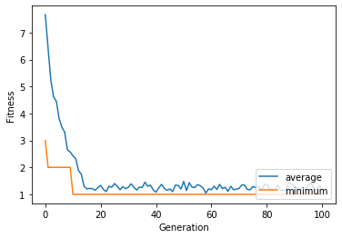

```python
gen, avg, min_,= log.select("gen", "avg", "min")

plt.plot(gen, avg, label="average")
plt.plot(gen, min_, label="minimum")
plt.xlabel("Generation")
plt.ylabel("Fitness")
plt.legend(loc="lower right")
plt.show()
```

Trial 2 (Increase Population)

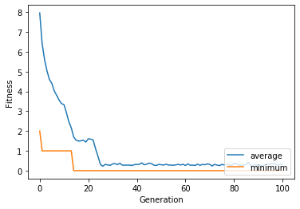

```python
gen, avg, min_,= log.select("gen", "avg", "min")

plt.plot(gen, avg, label="average")
plt.plot(gen, min_, label="minimum")
plt.xlabel("Generation")
plt.ylabel("Fitness")
plt.legend(loc="lower right")
plt.show()
```

Trial 3 (Increase Crossover)

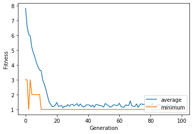

```python
gen, avg, min_,= log.select("gen", "avg", "min")

plt.plot(gen, avg, label="average")
plt.plot(gen, min_, label="minimum")
plt.xlabel("Generation")
plt.ylabel("Fitness")
plt.legend(loc="lower right")
plt.show()
```

Trial 4 (Increase Mutation Probability)

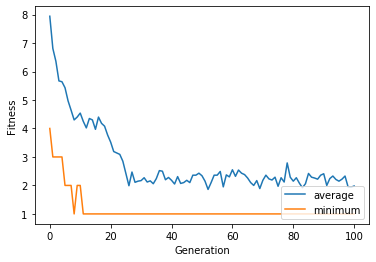

```python
gen, avg, min_,= log.select("gen", "avg", "min")

plt.plot(gen, avg, label="average")
plt.plot(gen, min_, label="minimum")
plt.xlabel("Generation")
plt.ylabel("Fitness")
plt.legend(loc="lower right")
plt.show()
```

Trial 5 (Increase Generation)

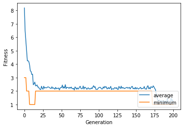

```python
gen, avg, min_,= log.select("gen", "avg", "min")

plt.plot(gen, avg, label="average")
plt.plot(gen, min_, label="minimum")
plt.xlabel("Generation")
plt.ylabel("Fitness")
plt.legend(loc="lower right")
plt.show()
```

Trial 6 (Best Combination of Parameters)

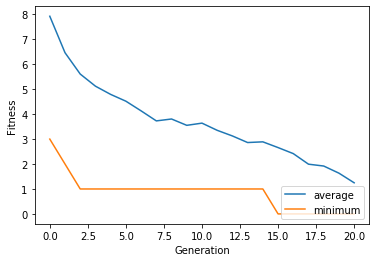

```python
gen, avg, min_,= log.select("gen", "avg", "min")

plt.plot(gen, avg, label="average")
plt.plot(gen, min_, label="minimum")
plt.xlabel("Generation")
plt.ylabel("Fitness")
plt.legend(loc="lower right")
plt.show()
```

### 5 pts: Print out the best individual found and its fitness value. Show the best individual as chessboard

Trial 6 HOF

```python
hof[0]
```

```
[4, 2, 0, 6, 1, 7, 5, 3]
```

```python
show_grid(hof[0])

print("\nwith fitness: ", hof[0].fitness)
```

```
-|-|-|-|X|-|-|-|
----------------
-|-|X|-|-|-|-|-|
----------------
X|-|-|-|-|-|-|-|
----------------
-|-|-|-|-|-|X|-|
----------------
-|X|-|-|-|-|-|-|
----------------
-|-|-|-|-|-|-|X|
----------------
-|-|-|-|-|X|-|-|
----------------
-|-|-|X|-|-|-|-|
----------------

with fitness:  (0.0,)
```